# Today we're going to learn about

- Python and IPython
- Numerical computing in Python using `numpy`

# Prerequisites

You need to have a distribution of Python installed, with all the modules we're going to use in this course.

The best way to ensure that is by installing the **Anaconda Scientific Python Distribution**:

- Go to http://continuum.io/downloads and follow the instructions for your platform

Once you're done:

```
$ python -V
Python 2.7.9 :: Anaconda 2.1.0 (x86_64)
```

# Anaconda on the Astro/Physics computer system

An installation of Anaconda Scientific Python Distribution (version 2.4) exists in:

```
/astro/apps6/opt/anaconda2.4
```

You can use it by adding it to your path:

```
[mjuric@magneto ~]$ export PATH="/astro/apps6/opt/anaconda2.4/bin:$PATH"
[mjuric@magneto ~]$ which python
/astro/apps6/opt/anaconda2.4/bin/python
```

# A Short Introduction to Python

Based on the notebooks by J.R. Johansson (robert@riken.jp) from http://github.com/jrjohansson/scientific-python-lectures.

## Note

I think most of you are familiar with basic Python (or can at least read it). Here, I'll largely concentrate on numerical (`numpy`) and plotting libraries (`matplotlib`). More topics (e.g., more advanced data analysis packages, databases, visualization) will be covered later.

If you don't have much experience with Python, there are a number of online resources/tutorials:

- [Software Carpentry Python Tutorials](http://software-carpentry.org/v4/python/)
- [A Crash Course in Python for Scientists, by Rick Muller](http://nbviewer.ipython.org/gist/rpmuller/5920182)
- [Scientific Python Lecture Notes](http://scipy-lectures.github.io)

as well as some excellent books:

- [Learning Python, by Mark Lutz](http://www.amazon.com/Learning-Python-Edition-Mark-Lutz/dp/1449355730)

## What is Python?

[Python](http://www.python.org/) is a modern, general-purpose, object-oriented, high-level programming language.

General characteristics of Python:

- **clean and simple language:** Easy-to-read and intuitive code, easy-to-learn minimalistic syntax, maintainability scales well with size of projects.
- **expressive language:** Fewer lines of code, fewer bugs, easier to maintain.

Technical details:

- **dynamically typed:** No need to define the type of variables, function arguments or return types.
- **automatic memory management:** No need to explicitly allocate and deallocate memory for variables and data arrays. No memory leak bugs.
- **interpreted:** No need to compile the code. The Python interpreter reads and executes the python code directly.

### Advantages:

- The main advantage is ease of programming, minimizing the time required to develop, debug and maintain the code.
- Well designed language that encourage many good programming practices:
  - Modular and object-oriented programming, good system for packaging and re-use of code. This often results in more transparent, maintainable and bug-free code.
  - Documentation tightly integrated with the code.
- A large standard library, and a large collection of add-on packages.

### Disadvantages:

- Since Python is an interpreted and dynamically typed programming language, the execution of python code can be slow compared to compiled statically typed programming languages, such as C and Fortran.
- Somewhat decentralized, with different environment, packages and documentation spread out at different places. Can make it harder to get started.

# What makes Python suitable for scientific computing?

[figure not shown]

- Python has a strong position in scientific computing:
  - Large community of users, easy to find help and documentation.
- Extensive ecosystem of scientific libraries and environments
  - `numpy`: http://numpy.scipy.org - Numerical Python
  - `scipy`: http://www.scipy.org - Scientific Python
  - `matplotlib`: http://www.matplotlib.org - graphics library
- Great performance due to close integration with time-tested and highly optimized codes written in C and Fortran:
  - blas, altas blas, lapack, arpack, Intel MKL, ...
- Readily available and suitable for use on high-performance computing clusters.
- No license costs, no unnecessary use of research budget.

## Python interpreter

The standard way to use the Python programming language is to use the Python interpreter to run python code. The python interpreter is a program that read and execute the python code in files passed to it as arguments. At the command prompt, the command `python` is used to invoke the Python interpreter.

For example, to run a file `my-program.py` that contains python code from the command prompt, use:

```
$ python my-program.py
```

## Python programs

- Python code is usually stored in text files with the file ending "`.py`":

  ```
    myprogram.py
  ```

- Every line in a Python program file is assumed to be a Python statement, or part thereof.
  - The only exception is comment lines, which start with the character `#` (optionally preceded by an arbitrary number of white-space characters, i.e., tabs or spaces). Comment lines are usually ignored by the Python interpreter.
- To run our Python program from the command line we use:

  ```
    $ python myprogram.py
  ```

- On UNIX systems it is common to define the path to the interpreter on the first line of the program (note that this is a comment line as far as the Python interpreter is concerned):

  ```
    #!/usr/bin/env python
  ```

  If we do, and if we additionally set the file script to be executable, we can run the program like this:

  ```
    $ myprogram.py
  ```

We can also start the interpreter by simply typing `python` at the command line, and interactively type python code into the interpreter.

[figure not shown]

This is often how we want to work when developing scientific applications, or when doing small calculations. But the standard python interpreter is not very convenient for this kind of work, due to a number of limitations.

### IPython (and Jupyter)

IPython is an interactive shell that addresses the limitation of the standard python interpreter, and it is a work-horse for scientific use of python. It provides an interactive prompt to the python interpreter with a greatly improved user-friendliness.

[figure not shown]

### Some of the many useful features of IPython include:

- Command history, which can be browsed with the up and down arrows on the keyboard.
- Tab auto-completion.
- In-line editing of code.
- Useful 'magic' commands (commands beginning with % and %%)
- Object introspection, and automatic extract of documentation strings from python objects like classes and functions.
- Good interaction with operating system shell.
- Support for multiple parallel back-end processes, that can run on computing clusters or cloud services like Amazon EE2.

### IPython notebook

[IPython notebook](http://ipython.org/notebook.html) is an HTML-based notebook environment for Python, similar to Mathematica or Maple. It is based on the IPython shell, but provides a cell-based environment with great interactivity, where calculations can be organized documented in a structured way.

[figure not shown]

Although using the a web browser as graphical interface, IPython notebooks are usually run locally, from the same computer that run the browser. To start a new IPython notebook session, run the following command:

```
$ ipython notebook
```

from a directory where you want the notebooks to be stored. This will open a new browser window (or a new tab in an existing window) with an index page where existing notebooks are shown and from which new notebooks can be created.

# IPython is one facet of Jupyter

What begun as IPython has grown beyond Python and morphed into Jupyter:

[figure not shown]

The Jupyter Notebook is a web application that allows you to create and share documents that contain live code (in many languages, Python just being one of them), equations, visualizations and explanatory text.

## Versions of Python

There are currently two versions of python: Python 2 and Python 3. Python 3 will eventually supercede Python 2, but it is not backward-compatible with Python 2. A lot of existing python code and packages has been written for Python 2, and it is still the most wide-spread version. For these lectures either version will be fine, but it is probably easier to stick with Python 2 for now, because it is more readily available via pre-built packages and binary installers.

To see which version of Python you have, run

```
$ python --version
Python 2.7.11 :: Anaconda 2.4.1 (x86_64)
$ python3.2 --version
Python 3.2.3
```

Several versions of Python can be installed in parallel, as shown above.

# Numpy - multidimensional data arrays

NumPy is an extension to the Python programming language, adding support for large, multi-dimensional arrays and matrices, along with a large library of high-level mathematical functions to operate on these arrays.

-- http://en.wikipedia.org/wiki/NumPy

## Why `numpy`?

Performance and ease of use.

The `numpy` package (module) is used in almost all numerical computation using Python. It is a package that provide high-performance vector, matrix and higher-dimensional data structures for Python. It is implemented in C and Fortran so when calculations are vectorized (formulated with vectors and matrices), performance is very good.

To use `numpy` need to import the module it using of example:

```python
import numpy as np
```

In the `numpy` package the terminology used for vectors, matrices and higher-dimensional data sets is *array*.

## Why `numpy`: Performance

Compared to C++ or FORTRAN, Python is *very* slow when operating on large lists (arrays) of data, using for loops.

```python
a = range(1000)
b = range(1000)
```

```python
%%timeit
c = []
for x in a:
    for y in b:
        c.append(x*y)
```

```
10 loops, best of 3: 124 ms per loop
```

```python
%%timeit
c = [ x*y for x in a for y in b ]
```

```
10 loops, best of 3: 72.6 ms per loop
```

Doing the same operation with numpy makes it run orders of magnitude faster

```python
a = np.arange(1000)
b = np.arange(1000)
%timeit c = a*b
```

```
The slowest run took 11.80 times longer than the fastest. This could mean that an intermediate result is being cached
1000000 loops, best of 3: 1.27 µs per loop
```

## Data analysis is performed on arrays (or tables) of data

Data analysis usually involves doing something with (large) tables of data.

For example:

- Convert all coordinates in a catalog from one coordinate system to another
- Compute colors for all observed objects
- Compute some statistic over a data set (means, medians, etc)
- Select subsets of the dataset based on some criterion

If we did this using Python `for`-loops, these operations would be very slow. Using `numpy` makes them run fast, and also makes the code more readable and compact.

## Creating `numpy` arrays

There are a number of ways to initialize new numpy arrays, for example from

- a Python list or tuples
- using functions that are dedicated to generating numpy arrays, such as `arange`, `linspace`, etc.
- reading data from files

### From lists

For example, to create new vector and matrix arrays from Python lists we can use the `numpy.array` function.

```python
# a vector: the argument to the array function is a Python list
v = np.array([1,2,3,4])

v
```

```
array([1, 2, 3, 4])
```

```python
# a matrix: the argument to the array function is a nested Python list
M = np.array([[1, 2], [3, 4]])

M
```

```
array([[1, 2],
       [3, 4]])
```

The `v` and `M` objects are both of the type `ndarray` that the `numpy` module provides.

```python
type(v), type(M)
```

```
(numpy.ndarray, numpy.ndarray)
```

The difference between the `v` and `M` arrays is only their shapes. We can get information about the shape of an array by using the `ndarray.shape` property.

```python
v.shape
```

```
(4,)
```

```python
M.shape
```

```
(2, 2)
```

The number of elements in the array is available through the `ndarray.size` property:

```python
M.size
```

```
4
```

Using the `dtype` (data type) property of an `ndarray`, we can see what type the data of an array has:

```python
M.dtype
```

```
dtype('int64')
```

We get an error if we try to assign a value of the wrong type to an element in a numpy array:

```python
M[0,0] = "hello"
```

```
---------------------------------------------------------------------------
ValueError                                Traceback (most recent call last)
<ipython-input-15-a09d72434238> in <module>()
----> 1 M[0,0] = "hello"

ValueError: invalid literal for long() with base 10: 'hello'
```

If we want, we can explicitly define the type of the array data when we create it, using the `dtype` keyword argument:

```python
M = np.array([[1, 2], [3, 4]], dtype=float)

M
```

```
array([[ 1.,  2.],
       [ 3.,  4.]])
```

Common type that can be used with `dtype` are: `int`, `float`, `complex`, `bool`, `object`, etc.

We can also explicitly define the bit size of the data types, for example: `int64`, `int16`, `float128`, `complex128`.

### Using array-generating functions

For larger arrays it is impractical to initialize the data manually, using explicit python lists. Instead we can use one of the many functions in `numpy` that generates arrays of different forms. Some of the more common are:

#### arange

```python
# create a range

x = np.arange(0, 10, 1) # arguments: start, stop, step

x
```

```
array([0, 1, 2, 3, 4, 5, 6, 7, 8, 9])
```

#### linspace and logspace

```python
# using linspace, both end points ARE included
np.linspace(0, 10, 25)
```

```
array([  0.        ,   0.41666667,   0.83333333,   1.25      ,
         1.66666667,   2.08333333,   2.5       ,   2.91666667,
         3.33333333,   3.75      ,   4.16666667,   4.58333333,
         5.        ,   5.41666667,   5.83333333,   6.25      ,
         6.66666667,   7.08333333,   7.5       ,   7.91666667,
         8.33333333,   8.75      ,   9.16666667,   9.58333333,  10.        ])
```

```python
np.logspace(0, 10, 10, base=e)
```

```
array([  1.00000000e+00,   3.03773178e+00,   9.22781435e+00,
         2.80316249e+01,   8.51525577e+01,   2.58670631e+02,
         7.85771994e+02,   2.38696456e+03,   7.25095809e+03,
         2.20264658e+04])
```

#### zeros and ones

```python
np.zeros((3,3))
```

```
array([[ 0.,  0.,  0.],
       [ 0.,  0.,  0.],
       [ 0.,  0.,  0.]])
```

```python
np.ones((3,3))
```

```
array([[ 1.,  1.,  1.],
       [ 1.,  1.,  1.],
       [ 1.,  1.,  1.]])
```

## Reading Data from Files

### Comma-separated values (CSV)

A very common file format for data files are the comma-separated values (CSV), or related format such as TSV (tab-separated values). To read data from such file into Numpy arrays we can use the `numpy.genfromtxt` function. For example,

```python
!head td_adj.dat
```

```
1800  1  1    -6.1    -6.1    -6.1 1
1800  1  2   -15.4   -15.4   -15.4 1
1800  1  3   -15.0   -15.0   -15.0 1
1800  1  4   -19.3   -19.3   -19.3 1
1800  1  5   -16.8   -16.8   -16.8 1
1800  1  6   -11.4   -11.4   -11.4 1
1800  1  7    -7.6    -7.6    -7.6 1
1800  1  8    -7.1    -7.1    -7.1 1
1800  1  9   -10.1   -10.1   -10.1 1
1800  1 10    -9.5    -9.5    -9.5 1
```

```python
data = np.genfromtxt('td_adj.dat')
```

```python
data.shape
```

```
(77431, 7)
```

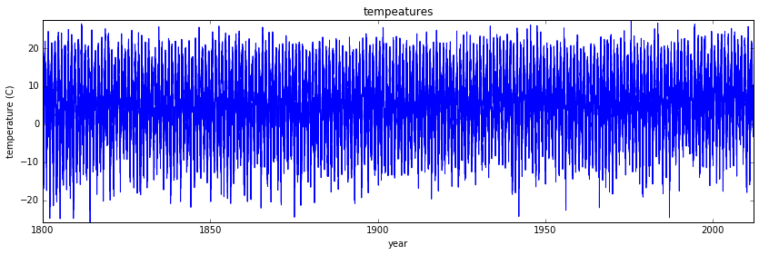

```python
# Note: I'm using the matplotlib library to create the plot below.
# We'll hear more about it next time.
fig, ax = subplots(figsize=(14,4))
ax.plot(data[:,0]+data[:,1]/12.0+data[:,2]/365, data[:,5])
ax.axis('tight')
ax.set_title('tempeatures')
ax.set_xlabel('year')
ax.set_ylabel('temperature (C)');
```

Using `numpy.savetxt` we can store a Numpy array to a file in CSV format:

```python
M = np.random.rand(3,3)

M
```

```
array([[ 0.60877555,  0.71775615,  0.71785107],
       [ 0.11223243,  0.64333541,  0.2522436 ],
       [ 0.67496486,  0.77140009,  0.62943134]])
```

```python
np.savetxt("random-matrix.csv", M)
```

```python
!cat random-matrix.csv
```

```
6.087755467012818666e-01 7.177561520278612495e-01 7.178510733732784699e-01
1.122324277808566251e-01 6.433354089437972601e-01 2.522435977819172948e-01
6.749648626625439629e-01 7.714000927598040347e-01 6.294313427069302413e-01
```

```python
np.savetxt("random-matrix.csv", M, fmt='%.5f') # fmt specifies the format

!cat random-matrix.csv
```

```
0.60878 0.71776 0.71785
0.11223 0.64334 0.25224
0.67496 0.77140 0.62943
```

# Reading formats common in astronomy

The most frequently used format is FITS. A very capable FITS reader and writer exists as a part of the [astropy](http://astropy.org) package.

Another common format is HDF5. See the [pytables](http://pytables.org) package for reading and writing HDF.

## Manipulating arrays

### Indexing

We can index elements in an array using the square bracket and indices:

```python
# v is a vector, and has only one dimension, taking one index
v[0]
```

```
1
```

```python
# M is a matrix, or a 2 dimensional array, taking two indices
M[1,1]
```

```
0.64333540894379726
```

If we omit an index of a multidimensional array it returns the whole row (or, in general, a N-1 dimensional array)

```python
M
```

```
array([[ 0.60877555,  0.71775615,  0.71785107],
       [ 0.11223243,  0.64333541,  0.2522436 ],
       [ 0.67496486,  0.77140009,  0.62943134]])
```

```python
M[1]
```

```
array([ 0.11223243,  0.64333541,  0.2522436 ])
```

The same thing can be achieved with using `:` instead of an index:

```python
M[1,:] # row 1
```

```
array([ 0.11223243,  0.64333541,  0.2522436 ])
```

```python
M[:,1] # column 1
```

```
array([ 0.71775615,  0.64333541,  0.77140009])
```

We can assign new values to elements in an array using indexing:

```python
M[0,0] = 1
```

```python
M
```

```
array([[ 1.        ,  0.71775615,  0.71785107],
       [ 0.11223243,  0.64333541,  0.2522436 ],
       [ 0.67496486,  0.77140009,  0.62943134]])
```

```python
# also works for rows and columns
M[1,:] = 0
M[:,2] = -1
```

```python
M
```

```
array([[ 1.        ,  0.71775615, -1.        ],
       [ 0.        ,  0.        , -1.        ],
       [ 0.67496486,  0.77140009, -1.        ]])
```

### Index slicing

Index slicing is the technical name for the syntax `M[lower:upper:step]` to extract part of an array:

```python
A = array([1,2,3,4,5])
A
```

```
array([1, 2, 3, 4, 5])
```

```python
A[1:3]
```

```
array([2, 3])
```

Array slices are *mutable*: if they are assigned a new value the original array from which the slice was extracted is modified:

```python
A[1:3] = [-2,-3]

A
```

```
array([ 1, -2, -3,  4,  5])
```

We can omit any of the three parameters in `M[lower:upper:step]`:

```python
A[::] # lower, upper, step all take the default values
```

```
array([ 1, -2, -3,  4,  5])
```

```python
A[::2] # step is 2, lower and upper defaults to the beginning and end of the array
```

```
array([ 1, -3,  5])
```

```python
A[:3] # first three elements
```

```
array([ 1, -2, -3])
```

```python
A[3:] # elements from index 3
```

```
array([4, 5])
```

Negative indices counts from the end of the array (positive index from the beginning):

```python
A = array([1,2,3,4,5])
```

```python
A[-1] # the last element in the array
```

```
5
```

```python
A[-3:] # the last three elements
```

```
array([3, 4, 5])
```

Index slicing works exactly the same way for multidimensional arrays:

```python
A = array([[n+m*10 for n in range(5)] for m in range(5)])

A
```

```
array([[ 0,  1,  2,  3,  4],
       [10, 11, 12, 13, 14],
       [20, 21, 22, 23, 24],
       [30, 31, 32, 33, 34],
       [40, 41, 42, 43, 44]])
```

```python
# a block from the original array
A[1:4, 1:4]
```

```
array([[11, 12, 13],
       [21, 22, 23],
       [31, 32, 33]])
```

```python
# strides
A[::2, ::2]
```

```
array([[ 0,  2,  4],
       [20, 22, 24],
       [40, 42, 44]])
```

### Fancy indexing

Fancy indexing is the name for when an array or list is used in-place of an index:

```python
row_indices = [1, 2, 3]
A[row_indices]
```

```
array([[10, 11, 12, 13, 14],
       [20, 21, 22, 23, 24],
       [30, 31, 32, 33, 34]])
```

```python
col_indices = [1, 2, -1] # remember, index -1 means the last element
A[row_indices, col_indices]
```

```
array([11, 22, 34])
```

We can also index masks: If the index mask is an Numpy array of with data type `bool`, then an element is selected (True) or not (False) depending on the value of the index mask at the position each element:

```python
B = np.arange(5)
B
```

```
array([0, 1, 2, 3, 4])
```

```python
row_mask = array([True, False, True, False, False])
B[row_mask]
```

```
array([0, 2])
```

```python
# same thing
row_mask = array([1,0,1,0,0], dtype=bool)
B[row_mask]
```

```
array([0, 2])
```

This feature is very useful to conditionally select elements from an array, using for example comparison operators:

```python
x = arange(0, 10, 0.5)
x
```

```
array([ 0. ,  0.5,  1. ,  1.5,  2. ,  2.5,  3. ,  3.5,  4. ,  4.5,  5. ,
        5.5,  6. ,  6.5,  7. ,  7.5,  8. ,  8.5,  9. ,  9.5])
```

```python
mask = (5 < x) & (x < 7.5)

mask
```

```
array([False, False, False, False, False, False, False, False, False,
       False, False,  True,  True,  True,  True, False, False, False,
       False, False], dtype=bool)
```

```python
x[mask]
```

```
array([ 5.5,  6. ,  6.5,  7. ])
```

## Functions for extracting data from arrays and creating arrays

### where

The index mask can be converted to position index using the `where` function

```python
indices = where(mask)

indices
```

```
(array([11, 12, 13, 14]),)
```

```python
x[indices] # this indexing is equivalent to the fancy indexing x[mask]
```

```
array([ 5.5,  6. ,  6.5,  7. ])
```

## Functions for extracting data from arrays and creating arrays

### diag

With the diag function we can also extract the diagonal and subdiagonals of an array:

```python
diag(A)
```

```
array([ 0, 11, 22, 33, 44])
```

```python
diag(A, -1)
```

```
array([10, 21, 32, 43])
```

## Functions for extracting data from arrays and creating arrays

### choose

Constructs and array by picking elements form several arrays:

```python
which = [1, 0, 1, 0]
choices = [[-2,-2,-2,-2], [5,5,5,5]]

choose(which, choices)
```

```
array([ 5, -2,  5, -2])
```

## Linear algebra

Vectorizing code is the key to writing efficient numerical calculation with Python/Numpy.

That means that as much as possible of a program should be formulated in terms of matrix and vector operations, like matrix-matrix multiplication.

### Scalar-array operations

We can use the usual arithmetic operators to multiply, add, subtract, and divide arrays with scalar numbers.

```python
v1 = np.arange(0, 5)
```

```python
v1 * 2
```

```
array([0, 2, 4, 6, 8])
```

```python
v1 + 2
```

```
array([2, 3, 4, 5, 6])
```

```python
A * 2, A + 2
```

```
(array([[ 0,  2,  4,  6,  8],
        [20, 22, 24, 26, 28],
        [40, 42, 44, 46, 48],
        [60, 62, 64, 66, 68],
        [80, 82, 84, 86, 88]]), array([[ 2,  3,  4,  5,  6],
        [12, 13, 14, 15, 16],
        [22, 23, 24, 25, 26],
        [32, 33, 34, 35, 36],
        [42, 43, 44, 45, 46]]))
```

### Element-wise array-array operations

When we add, subtract, multiply and divide arrays with each other, the default behaviour is **element-wise** operations:

```python
A * A # element-wise multiplication
```

```
array([[   0,    1,    4,    9,   16],
       [ 100,  121,  144,  169,  196],
       [ 400,  441,  484,  529,  576],
       [ 900,  961, 1024, 1089, 1156],
       [1600, 1681, 1764, 1849, 1936]])
```

```python
v1 * v1
```

```
array([ 0,  1,  4,  9, 16])
```

If we multiply arrays with compatible shapes, we get an element-wise multiplication of each row:

```python
A.shape, v1.shape
```

```
((5, 5), (5,))
```

```python
A * v1
```

```
array([[  0,   1,   4,   9,  16],
       [  0,  11,  24,  39,  56],
       [  0,  21,  44,  69,  96],
       [  0,  31,  64,  99, 136],
       [  0,  41,  84, 129, 176]])
```

### Matrix algebra

What about matrix mutiplication? There are two ways. We can either use the `dot` function, which applies a matrix-matrix, matrix-vector, or inner vector multiplication to its two arguments:

```python
np.dot(A, A)
```

```
array([[ 300,  310,  320,  330,  340],
       [1300, 1360, 1420, 1480, 1540],
       [2300, 2410, 2520, 2630, 2740],
       [3300, 3460, 3620, 3780, 3940],
       [4300, 4510, 4720, 4930, 5140]])
```

```python
dot(A, v1)
```

```
array([ 30, 130, 230, 330, 430])
```

```python
dot(v1, v1)
```

```
30
```

See also the related functions: `inner`, `outer`, `cross`, `kron`, `tensordot`. Try for example `help(kron)`.

There are many other functions for matrix computations: `inv`, `det`, etc.

### Data processing

Often it is useful to store datasets in Numpy arrays. Numpy provides a number of functions to calculate statistics of datasets in arrays.

For example, let's calculate some properties data from the Stockholm temperature dataset used above.

```python
# reminder, the temperature dataset is stored in the data variable:
shape(data)
```

```
(77431, 7)
```

#### mean

```python
# the temperature data is in column 3
mean(data[:,3])
```

```
6.1971096847515854
```

The daily mean temperature in Stockholm over the last 200 year so has been about 6.2 C.

#### standard deviations and variance

```python
std(data[:,3]), var(data[:,3])
```

```
(8.2822716213405734, 68.596023209663414)
```

#### min and max

```python
# lowest daily average temperature
data[:,3].min()
```

```
-25.800000000000001
```

```python
# highest daily average temperature
data[:,3].max()
```

```
28.300000000000001
```

#### sum, prod, and trace

```python
d = arange(0, 10)
d
```

```
array([0, 1, 2, 3, 4, 5, 6, 7, 8, 9])
```

```python
# sum up all elements
sum(d)
```

```
45
```

```python
# product of all elements
prod(d+1)
```

```
3628800
```

```python
# cummulative sum
cumsum(d)
```

```
array([ 0,  1,  3,  6, 10, 15, 21, 28, 36, 45])
```

```python
# cummulative product
cumprod(d+1)
```

```
array([      1,       2,       6,      24,     120,     720,    5040,
         40320,  362880, 3628800])
```

```python
# same as: diag(A).sum()
trace(A)
```

```
110
```

## Reshaping, resizing and stacking arrays

The shape of an Numpy array can be modified without copying the underlaying data, which makes it a fast operation even for large arrays.

```python
A
```

```
array([[ 0,  1,  2,  3,  4],
       [10, 11, 12, 13, 14],
       [20, 21, 22, 23, 24],
       [30, 31, 32, 33, 34],
       [40, 41, 42, 43, 44]])
```

```python
n, m = A.shape
```

```python
B = A.reshape((1,n*m))
B
```

```
array([[ 0,  1,  2,  3,  4, 10, 11, 12, 13, 14, 20, 21, 22, 23, 24, 30, 31,
        32, 33, 34, 40, 41, 42, 43, 44]])
```

```python
B[0,0:5] = 5 # modify the array

B
```

```
array([[ 5,  5,  5,  5,  5, 10, 11, 12, 13, 14, 20, 21, 22, 23, 24, 30, 31,
        32, 33, 34, 40, 41, 42, 43, 44]])
```

```python
A # and the original variable is also changed. B is only a different view of the same data
```

```
array([[ 5,  5,  5,  5,  5],
       [10, 11, 12, 13, 14],
       [20, 21, 22, 23, 24],
       [30, 31, 32, 33, 34],
       [40, 41, 42, 43, 44]])
```

We can also use the function `flatten` to make a higher-dimensional array into a vector. But this function create a copy of the data.

```python
B = A.flatten()

B
```

```
array([ 5,  5,  5,  5,  5, 10, 11, 12, 13, 14, 20, 21, 22, 23, 24, 30, 31,
       32, 33, 34, 40, 41, 42, 43, 44])
```

```python
B[0:5] = 10

B
```

```
array([10, 10, 10, 10, 10, 10, 11, 12, 13, 14, 20, 21, 22, 23, 24, 30, 31,
       32, 33, 34, 40, 41, 42, 43, 44])
```

```python
A # now A has not changed, because B's data is a copy of A's, not refering to the same data
```

```
array([[ 5,  5,  5,  5,  5],
       [10, 11, 12, 13, 14],
       [20, 21, 22, 23, 24],
       [30, 31, 32, 33, 34],
       [40, 41, 42, 43, 44]])
```

## Stacking and repeating arrays

Using function `repeat`, `tile`, `vstack`, `hstack`, and `concatenate` we can create larger vectors and matrices from smaller ones:

### tile and repeat

```python
a = array([[1, 2], [3, 4]])
```

```python
# repeat each element 3 times
repeat(a, 3)
```

```
array([1, 1, 1, 2, 2, 2, 3, 3, 3, 4, 4, 4])
```

```python
# tile the matrix 3 times
tile(a, 3)
```

```
array([[1, 2, 1, 2, 1, 2],
       [3, 4, 3, 4, 3, 4]])
```

### concatenate

```python
b = array([[5, 6]])
b
```

```
array([[5, 6]])
```

```python
concatenate((a, b), axis=0)
```

```
array([[1, 2],
       [3, 4],
       [5, 6]])
```

```python
concatenate((a, b.T), axis=1)
```

```
array([[1, 2, 5],
       [3, 4, 6]])
```

### Alternative: vstack and hstack

```python
vstack((a,b))
```

```
array([[1, 2],
       [3, 4],
       [5, 6]])
```

```python
hstack((a,b.T))
```

```
array([[1, 2, 5],
       [3, 4, 6]])
```

## Copy and "deep copy"

To achieve high performance, assignments in Python usually do not copy the underlaying objects. This is important for example when objects are passed between functions, to avoid an excessive amount of memory copying when it is not necessary (technical term: pass by reference).

```python
A = array([[1, 2], [3, 4]])

A
```

```
array([[1, 2],
       [3, 4]])
```

```python
# now B is referring to the same array data as A
B = A
```

```python
# changing B affects A
B[0,0] = 10

B
```

```
array([[10,  2],
       [ 3,  4]])
```

```python
A
```

```
array([[10,  2],
       [ 3,  4]])
```

If we want to avoid this behavior, so that when we get a new completely independent object `B` copied from `A`, then we need to do a so-called "deep copy" using the function `copy`:

```python
B = copy(A)
```

```python
# now, if we modify B, A is not affected
B[0,0] = -5

B
```

```
array([[-5,  2],
       [ 3,  4]])
```

```python
A
```

```
array([[10,  2],
       [ 3,  4]])
```

## Iterating over array elements

Generally, we want to avoid iterating over the elements of arrays whenever we can (at all costs). The reason is that in a interpreted language like Python (or MATLAB), iterations are really slow compared to vectorized operations.

However, sometimes iterations are unavoidable. For such cases, the Python `for` loop is the most convenient way to iterate over an array:

```python
v = array([1,2,3,4])

for element in v:
    print(element)
```

```
1
2
3
4
```

```python
M = array([[1,2], [3,4]])

for row in M:
    print("row", row)

    for element in row:
        print(element)
```

```
('row', array([1, 2]))
1
2
('row', array([3, 4]))
3
4
```

When we need to iterate over each element of an array and modify its elements, it is convenient to use the `enumerate` function to obtain both the element and its index in the `for` loop:

```python
for row_idx, row in enumerate(M):
    print("row_idx", row_idx, "row", row)

    for col_idx, element in enumerate(row):
        print("col_idx", col_idx, "element", element)

        # update the matrix M: square each element
        M[row_idx, col_idx] = element ** 2
```

```
('row_idx', 0, 'row', array([1, 2]))
('col_idx', 0, 'element', 1)
('col_idx', 1, 'element', 2)
('row_idx', 1, 'row', array([3, 4]))
('col_idx', 0, 'element', 3)
('col_idx', 1, 'element', 4)
```

```python
# each element in M is now squared
M
```

```
array([[ 1,  4],
       [ 9, 16]])
```

## Performance

```python
%%timeit
M = array([[1,2], [3,4]])
for row_idx, row in enumerate(M):
    for col_idx, element in enumerate(row):
        # update the matrix M: square each element
        M[row_idx, col_idx] = element ** 2
```

```
The slowest run took 4.53 times longer than the fastest. This could mean that an intermediate result is being cached
100000 loops, best of 3: 6.16 µs per loop
```

```python
M = array([[1,2], [3,4]])
%timeit M*M
```

```
The slowest run took 24.42 times longer than the fastest. This could mean that an intermediate result is being cached
1000000 loops, best of 3: 449 ns per loop
```

```python
M
```

```
array([[1, 2],
       [3, 4]])
```

## Using arrays in conditions

When using arrays in conditions in for example `if` statements and other boolean expressions, one need to use one of `any` or `all`, which requires that any or all elements in the array evaluates to `True`:

```python
M
```

```
array([[1, 2],
       [3, 4]])
```

```python
if (M > 5).any():
    print("at least one element in M is larger than 5")
else:
    print("no element in M is larger than 5")
```

```
no element in M is larger than 5
```

```python
if (M > 5).all():
    print("all elements in M are larger than 5")
else:
    print("all elements in M are not larger than 5")
```

```
all elements in M are not larger than 5
```

### Putting it all together: data analysis with numpy+python

We can analyze data using indexing, fancy indexing, and the other methods of extracting data from an array (described above).

For example, let's go back to the temperature dataset:

```python
!head -n 3 td_adj.dat
```

```
1800  1  1    -6.1    -6.1    -6.1 1
1800  1  2   -15.4   -15.4   -15.4 1
1800  1  3   -15.0   -15.0   -15.0 1
```

The dataformat is: year, month, day, daily average temperature, low, high, location.

If we are interested in the average temperature only in a particular month, say February, then we can create a index mask and use the select out only the data for that month using:

```python
np.unique(data[:,1]) # the month column takes values from 1 to 12
```

```
array([  1.,   2.,   3.,   4.,   5.,   6.,   7.,   8.,   9.,  10.,  11.,
        12.])
```

```python
mask_feb = data[:,1] == 2
```

The array mask_feb is set to 'True' at locations where the 1st column in data equals 2:

```python
data[mask_feb][:,1]
```

```
array([ 2.,  2.,  2., ...,  2.,  2.,  2.])
```

```python
# the temperature data is in column 3
np.mean(data[mask_feb,3])
```

```
-3.2121095707365961
```

With these tools we have very powerful data processing capabilities at our disposal. For example, to extract the average monthly average temperatures for each month of the year only takes a few lines of code:

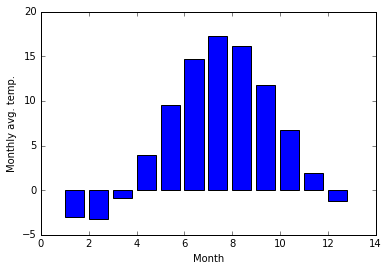

```python
months = arange(1,13)
monthly_mean = [ mean( data[data[:,1] == month, 3] ) for month in months]

fig, ax = subplots()
ax.bar(months, monthly_mean)
ax.set_xlabel("Month")
ax.set_ylabel("Monthly avg. temp.");
```

We will see more (astronomical) examples of this kind later in the quarter.

## Further reading

- http://numpy.scipy.org
- http://scipy.org/Tentative_NumPy_Tutorial
- http://scipy.org/NumPy_for_Matlab_Users - A Numpy guide for MATLAB users.

# Until next time...

## To get the necessary software (and some practice)

1. Install the Anaconda Python Distribution
2. Download this IPython notebook from the class github repository (https://github.com/mjuric/astr597b_wi16)
3. Open the notebook and evaluate all cells